# Epigenetic analysis of fetail brain from human monozygotic twins

Gloria Li  
Tue Mar 11 16:30:17 2014

## Neuroshpere cortex derived VS neuroshpere ganglionic eminence derived

### Differential expression analysis

RNA-seq of Neuroshpere cortex derived VS neuroshpere ganglionic eminence derived from HuFNSC01, 02, 03, 04.  
Use DEfine (FDR cutoff = 0.01) on normalized RPKMs of each gene to idetify DE genes between cortex and GE.

**No. of DE genes**

| Sample | Cortex.Overexpression | GE.Overexpression |
| --- | --- | --- |
| HuFNSC01 | 403 | 508 |
| HuFNSC02 | 588 | 640 |
| HuFNSC03 | 447 | 227 |
| HuFNSC04 | 378 | 249 |
| 2 or more | 382 | 456 |

**DAVID enrichment**:  
Both cortex overexpressed and GE overexpressed genes are enriched in brain development related terms.  
GE overexpressed genes are enriched in EGF-like protein domain.

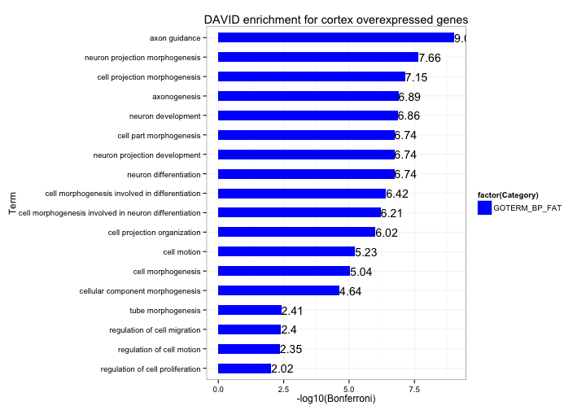

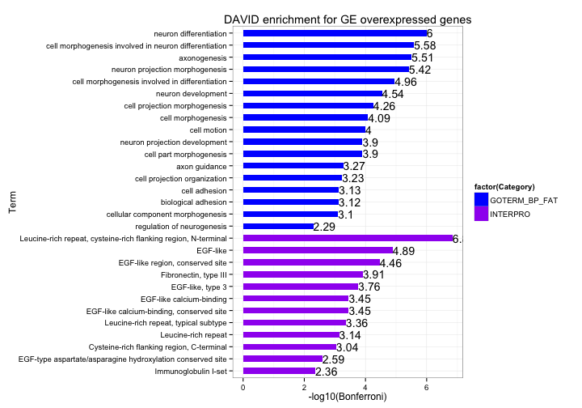

### Isoform analysis

RNA-seq of Neuroshpere cortex derived VS neuroshpere ganglionic eminence derived from HuFNSC01, 02, 03, 04.  
Use DEfine (FDR cut-off = 0.01) on normalized RPKMs of each exon to idetify DE exons between cortex and GE. Expressed exons were defined as those with RPKM ≥ 10% of gene RPKM; unexpressed exons were defined as those with RPKM ≤ 1% of gene RPKM; and the exons in between (1~10% gene RPKM) were discarded to filter out most false positives. Isoforms for each pairwise comparison were identified as genes with DE exons expressed in only one of the two samples.

### DNA methylation analysis

MethylCRF of HuFNSC01 and 02.  
DMRs: calculate average methylation level for 1kB bins. Fold change between two samlpes > 2. And methylCRF value of one sample > 0.5.

**No. of DMRs**:

| Sample | DMRs | Promoter | Promoter.Enrichment | PC.Promoter | DE.pcPromoter | Genebody | PC.Genebody | CGI | CGI.Enrichment |
| --- | --- | --- | --- | --- | --- | --- | --- | --- | --- |
| HuFNSC01 | 3638 | 620 | 2.56 | 330 | 15 | 1620 | 1215 | 95 | 1.63 |
| HuFNSC02 | 4712 | 829 | 2.65 | 418 | 22 | 2160 | 1654 | 132 | 1.75 |
| Shared | 1215 | 172 | 2.13 | 84 | 4 | 571 | 429 | 60 | 3.08 |

**Global differential methylation trend**

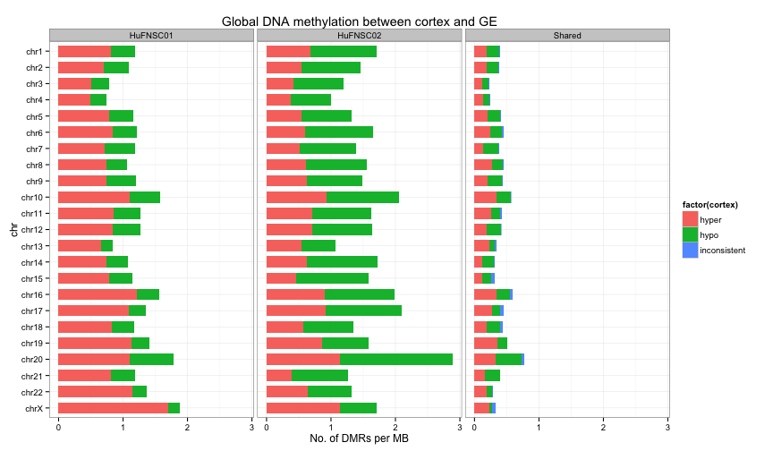

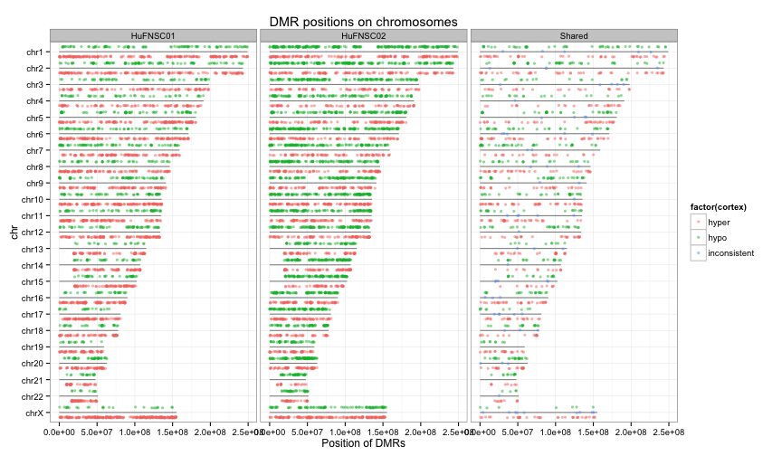

**Differential methylated in promoters and differential expressed genes**  
[1] “HuFNSC01”

| ID | Gene.Name |
| --- | --- |
| ENSG00000182132 | Kv channel interacting protein 1 |
| ENSG00000057657 | PR domain containing 1, with ZNF domain |
| ENSG00000175899 | alpha-2-macroglobulin |
| ENSG00000091879 | angiopoietin 2 |
| ENSG00000134115 | contactin 6 |
| ENSG00000164687 | fatty acid binding protein 5-like 25 (psoriasis-associated)5-like 85-like 75-like 9 |
| ENSG00000172461 | fucosyltransferase 9 (alpha (1,3) fucosyltransferase) |
| ENSG00000115738 | inhibitor of DNA binding 2, dominant negative helix-loop-helix protein |
| ENSG00000125414 | myosin, heavy chain 2, skeletal muscle, adult |
| ENSG00000179915 | neurexin 1 |
| ENSG00000198929 | nitric oxide synthase 1 (neuronal) adaptor protein |
| ENSG00000185551 | nuclear receptor subfamily 2, group F, member 2 |
| ENSG00000168301 | potassium channel tetramerisation domain containing 6 |
| ENSG00000005108 | thrombospondin, type I, domain containing 7A |
| ENSG00000182223 | zygote arrest 1 |

[1] “HuFNSC02”

| ID | Gene.Name |
| --- | --- |
| ENSG00000171476 | HOP homeobox |
| ENSG00000148926 | adrenomedullin |
| ENSG00000140945 | cadherin 13, H-cadherin (heart) |
| ENSG00000107159 | carbonic anhydrase IX |
| ENSG00000108691 | chemokine (C-C motif) ligand 2 |
| ENSG00000011465 | decorin |
| ENSG00000185610 | developing brain homeobox 2 |
| ENSG00000131095 | glial fibrillary acidic protein |
| ENSG00000115738 | inhibitor of DNA binding 2, dominant negative helix-loop-helix protein |
| ENSG00000108231 | leucine-rich, glioma inactivated 1 |
| ENSG00000198929 | nitric oxide synthase 1 (neuronal) adaptor protein |
| ENSG00000008441 | nuclear factor I/X (CCAAT-binding transcription factor) |
| ENSG00000165588 | orthodenticle homeobox 2 |
| ENSG00000118785 | secreted phosphoprotein 1 |
| ENSG00000143416 | selenium binding protein 1 |
| ENSG00000157404 | similar to Mast/stem cell growth factor receptor precursor (SCFR) (Proto-oncogene tyrosine-protein kinase Kit) (c-kit) (CD117 antigen)-kit Hardy-Zuckerman 4 feline sarcoma viral oncogene homolog |
| ENSG00000203815 | similar to UPF0627 protein ENSP00000358171388692 |
| ENSG00000005108 | thrombospondin, type I, domain containing 7A |
| ENSG00000112715 | vascular endothelial growth factor A |
| ENSG00000171940 | zinc finger protein 217 |
| ENSG00000165424 | zinc finger, CCHC domain containing 24 |
| ENSG00000182223 | zygote arrest 1 |

[1] “Shared”

| ID | Gene.Name |
| --- | --- |
| ENSG00000115738 | inhibitor of DNA binding 2, dominant negative helix-loop-helix protein |
| ENSG00000198929 | nitric oxide synthase 1 (neuronal) adaptor protein |
| ENSG00000005108 | thrombospondin, type I, domain containing 7A |
| ENSG00000182223 | zygote arrest 1 |

**GREAT annotation on all DMRs**

- InterPro of both individuals and their shared DMRs are enriched for Homeobox domain.
- GO molecular functions show enrichment related to transciprtion regulation.

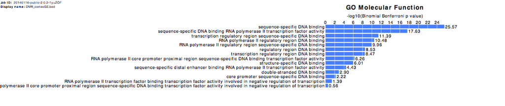

- GO biological processes in both individuals show terms in brain and kidney development, but in shared DMRs, only brain development terms are enriched.
  - HuFNSC01

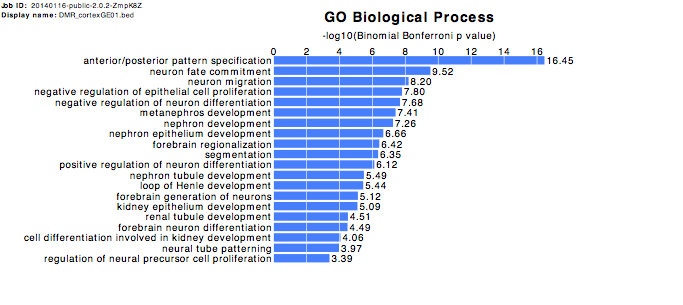

  - HuFNSC02

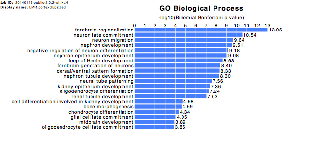

  - Share DMRs

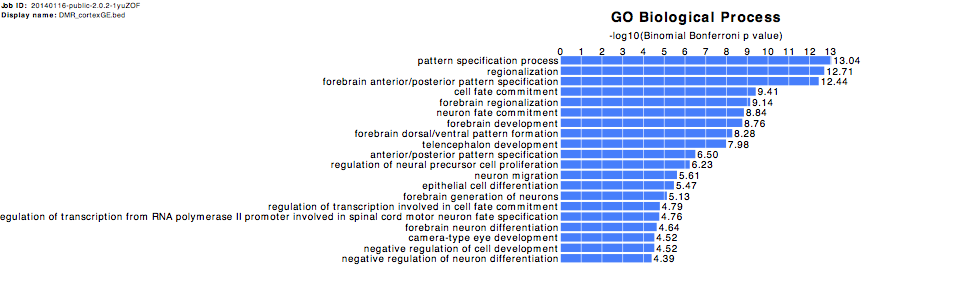

**GREAT annotation on protein-coding promoter DMRs**

Protein-coding promoter DMRs from both individuals show significant enrichment for olfactory/sensory related terms, but there is no enrichment for shared pc promoter DMRs.

- GO molecular functions
  - HuFNSC01

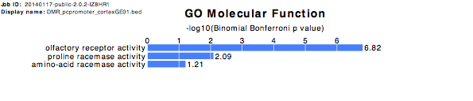

  - HuFNSC02

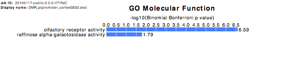

- GO biological processes
  - HuFNSC01

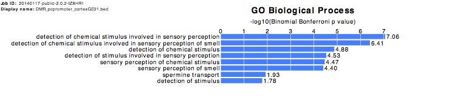

  - HuFNSC02

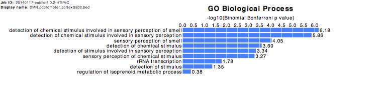

- MSigDB pathway
  - HuFNSC01

[figure not shown]

  - HuFNSC02

[figure not shown]

- InterPro
  - HuFNSC01

[figure not shown]

  - HuFNSC02

[figure not shown]

**GREAT annotation on non-coding promoter DMRs**

Non-coding promoter DMRs from both individuals and their shared DMRs are enriched in terms related to kidney development. Both HuFNSC01 and HuFNSC02 have enriched terms in brain development, but their shared DMRs do not.

- GO biological processes
  - Shared DMRs

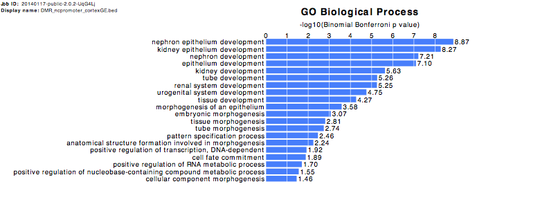

  - HuFNSC01

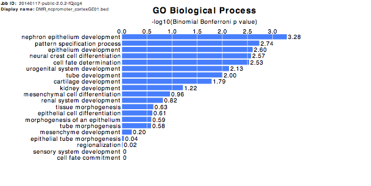

  - HuFNSC02

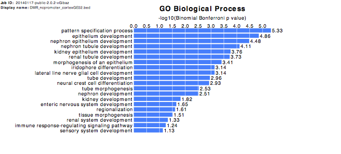

**GREAT annotation on CGI DMRs**

Enrichment in CGI DMRs are highly consistent between HuFNSC01 and HuFNSC02 and their shared DMRs.

- GO molecular function show enrichment in DNA-binding and transcription regulation related terms.

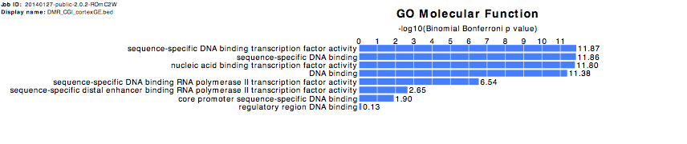

- GO biological process show enrichment in brain development and expression regulation terms.

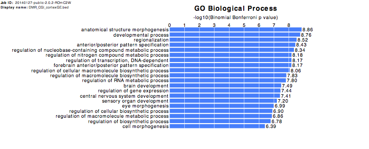

- InterPro show significant enrichment in Homeobox domain.

[figure not shown]

**DAVID annotation on protein-coding genebody DMRs**

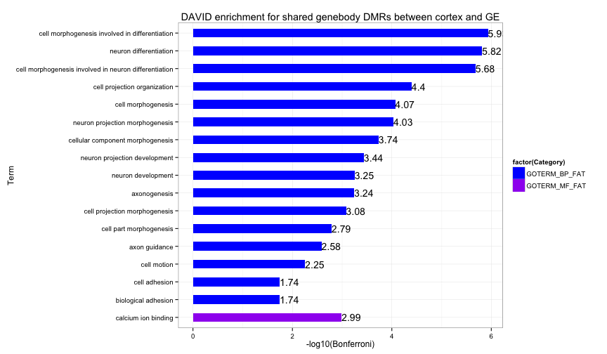

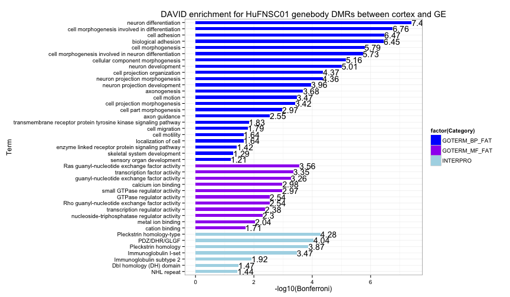

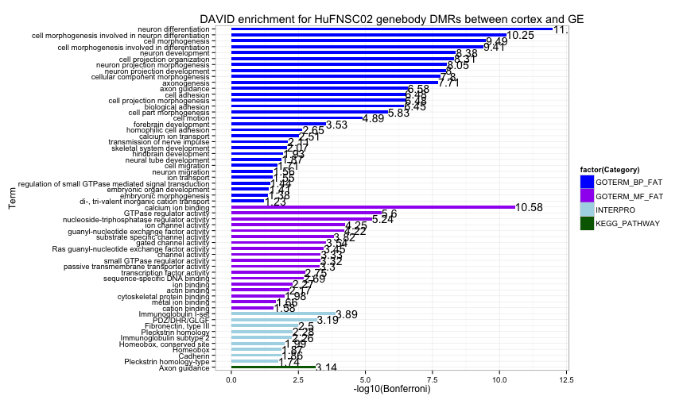

## Between monozygotic twins

### Differential expression analysis

**No. of DE genes**

| Sample | UP | DN |
| --- | --- | --- |
| Brain_01vs02 | 461 | 181 |
| Cortex_01vs02 | 248 | 348 |
| GE_01vs02 | 99 | 74 |
| Cortex_03vs04 | 459 | 183 |
| GE_03vs04 | 313 | 232 |

### DNA methylation analysis

MethylCRF of HuFNSC01 and 02 on brain, cortex and GE.  
DMRs: calculate average methylation level for 1kB bins. Fold change between two samlpes > 2. And methylCRF value of one sample > 0.5.

**No. of DMRs**:

| Sample | DMRs | Promoter | Promoter.Enrichment | PC.Promoter | DE.pcPromoter | Genebody | PC.Genebody | CGI | CGI.Enrichment |
| --- | --- | --- | --- | --- | --- | --- | --- | --- | --- |
| Brain | 5442 | 864 | 2.39 | 467 | 13 | 2650 | 2165 | 59 | 0.68 |
| Cortex | 2809 | 649 | 3.47 | 391 | 8 | 1178 | 887 | 37 | 0.82 |
| GE | 2225 | 572 | 3.87 | 329 | 2 | 879 | 619 | 28 | 0.79 |

**Global differential methylation trend**

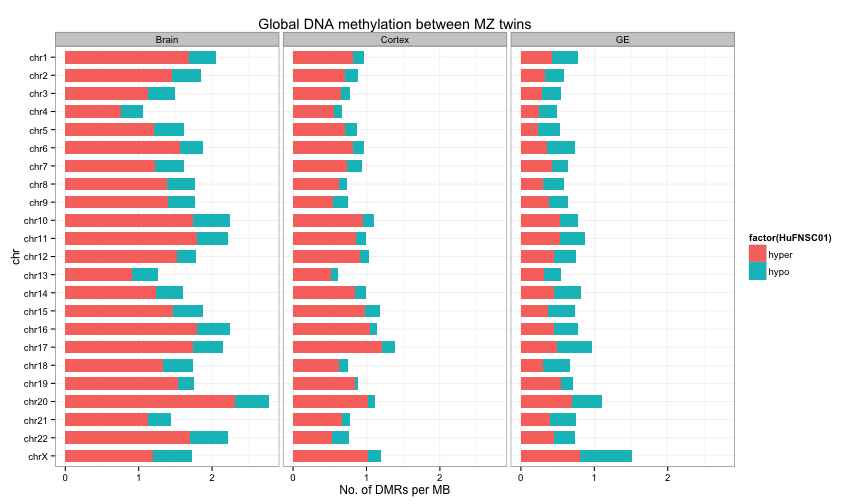

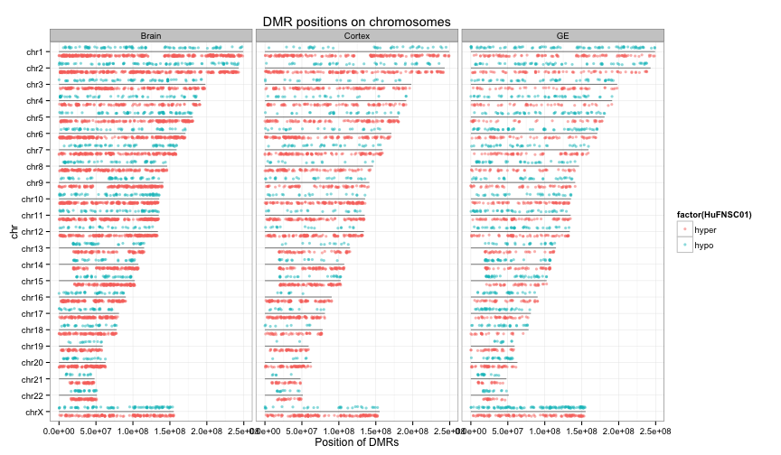

**Differential methylated in promoters and differential expressed genes**

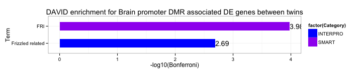

**GREAT annotation on all DMRs**

- Brain: enrichment in biological processes related to brain development and vision development in particular.

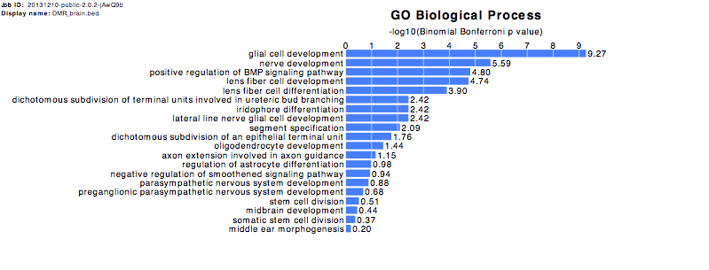

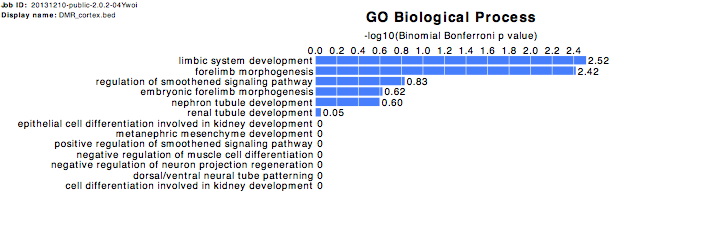

- GE: brain development related terms barely reached significance level. Also show enrichment in kidney development.

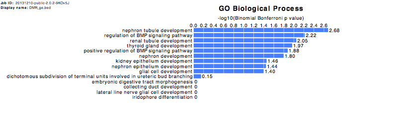

**GREAT annotation on protein-coding promoter DMRs**